# Quiz 1: District crime

Xiyu Zhang

2022-10-17

## Overview

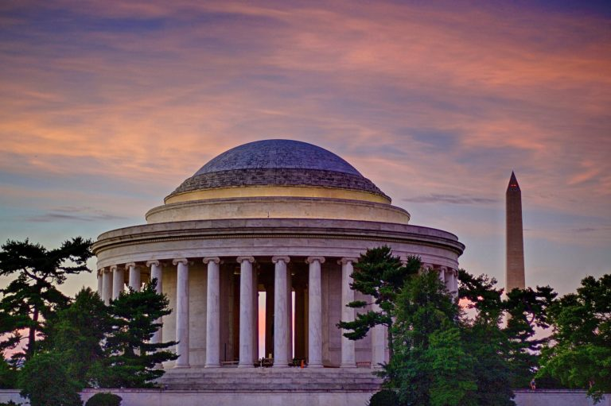

In this exercise, you will explore crime data from the District of Columbia in 2020. The data for this exercise were retrieved from [Open Data DC](https://opendata.dc.gov/) in October of 2021 and contain the location of crimes in the city, as reported by the District of Columbia Metropolitan Police Department. Each crime record includes the geographic coordinates of the crime (recorded in EPSG 4326), the date and time it occurred, whether it was a *violent* or *property* crime, and the type of offense. Your job will be to generate maps of these crimes across the District.

This exercise will give you an opportunity to test your *sf*, *purrr::map*, and *tmap* skills!

**Important**

To receive full credit for a given question, please ensure that the result you provide **only** answers the given question. For example, in the table below, if you were asked to determine the value in column `b` where column `a` is equal to “hello” you would provide the following code:

```r
tibble(
  a = c('hello', 'world'),
  b = 1:2) %>%
  filter(a == 'hello') %>%
  pull(b)
```

```
## [1] 1
```

## Grading

The points allotted for each question are provided in highlighted red bold text (e.g., [1.0]) within the question itself. When applicable, total points for a question may represent the sum of individually graded components, which are provided in red text (e.g., [1.0]).

**Points may be deducted from each question’s total:**

- Use only functions other than those listed in “Functions that you may use in this exercise” [50%]
- Do not include any assignments other than those specified in the question [50%]
- Unless specified otherwise, each question must be answered in a single piped statement [50%]
- Include a comment at the start of each code block [25%]
- Include a comment for each line of code that modifies a dataset [10% per violation]
- Ensure that all code is properly indented [10% per violation]
- Ensure that your code follows modern coding conventions (see *Best practices in modern R coding*) [10% per violation]
- Code parsimony [10% per violation]

*Note: The maximum deduction is the total points value for a given question*

In this exercise, you may use **only** the following R functions (*Note: If you are unclear on what a given function does, use `?` to view the help file!*):

- base::<-
- base::=
- base::(
- base::)
- base::$
- base::!
- base::~
- base::==
- base::c
- base::library
- base::list
- base::names
- base::tolower
- base::unique
- dplyr::filter
- dplyr::group_by
- dplyr::inner_join
- dplyr::n
- dplyr::pull
- dplyr::select
- dplyr::summarize
- lubridate::year
- magrittr::%>%
- purrr::map
- readr::read_csv
- sf::st_as_sf
- sf::st_crs
- sf::st_filter
- sf::st_join
- sf::st_read
- sf::st_transform
- readr::read_csv
- rlang::set_names
- tibble::as_tibble
- tmap::+
- tmap::tm_basemap
- tmap::tm_dots
- tmap::tm_layout
- tmap::tmap_mode
- tmap::tm_shape
- tmap::tm_polygons
- tmaptools::palette_explorer

**Note**: The packages dplyr, ggplot2, magrittr, readr, rlang, and tibble are all part of the tidyverse and are loaded with `library(tidyverse)`.

## Getting started

Open R Studio. Please ensure that the Global Options for R Markdown are set to “Show output preview in Viewer Pane”. This will allow you to view the knitted document (i.e., the html version of this file) right next to your code.

As always, please ensure that you are starting with a clean session. Please do the following before continuing:

- If there are any script files open in your source pane. Close them. If any of the file titles are blue, save them prior to closing.
- In the *Environment* tab of your **workspace pane**, ensure that your **global environment** is empty. If it is not, click the *broom* to remove all objects.
- In the *History* tab of your **workspace pane**, ensure that your history is empty. If it is not, click the *broom* to remove your history.

1. [0.5] Save you R script file as (*but replace my name with yours*): `quiz_1_Evans_Brian.R`.

## The setup

**All** of my scripts start with a setup section where I load libraries, set session options, conduct initial data loading, and early processing steps.

```r
# setup ------------------------

library(sf)
library(lubridate)
library(tmap)
library(tidyverse)

# Read in and process census data:

census <-
  st_read('data/raw/shapefiles/dc_census.geojson') %>%
  set_names(
    names(.) %>%
      tolower()) %>%
  select(!statefp)

# Read in and process crimes data:

crimes <-
  read_csv('data/raw/dc_crimes.csv') %>%

  # Subset to violent crimes in 2020:

  filter(offense_group == 'violent',
         year(date_time) == 2020) %>%

  # Make spatial:

  st_as_sf(
    coords = c('longitude', 'latitude'),
    crs = 4326) %>%

  # Transform to the same CRS as census:

  st_transform(crs = st_crs(census))

# A vector of unique offenses:

offenses <-
  crimes %>%
  pull(offense) %>%
  unique()
```

2. [1.5]. Using `purrr::map()` and the `offenses`, `crimes`, `census` objects:

- [1.0] Generate a list of shapefiles that tallies the number of violent crimes committed by census tract and `offense`. You should have one shapefile per type of offense.
- [0.25] Name your list items by offense type.
- [0.25]Assign the list to your global environment with the name “crimes_by_offense”.

3. [0.5] Using a single `purrr::map()` function, transform the CRS of `crimes_by_offense` to 4326 [0.25] and assign the object to your global environment with the name `crimes_by_offense_4326` [0.25].

4. [1.0] Using a single `purrr::map()` function:

- [0.5] Convert the CRS of `crimes` and `census` objects to EPSG 4326;
- [0.25] Assign the names “crimes” and “census” to the list items;
- [0.25] Assign the list to your global environment with the name `shapes_4326`.

5. [1.5] Using `shapes_4326` and `crimes_by_offense_4326`, generate an interactive tmap [0.5] where:

- [0.25] The fill color of census tracts is determined by the number of robberies in a given tract;
- [0.25] Homicides are displayed as clusters of points;
- [0.25] OpenStreetMap and Esri.WorldImagery are provided as background layers;
- [0.25] The layers are named “Robberies” and “Homicides”.